[figure not shown]

# PTM Statistics: DPA, DPU, and CorrectFirst

**Overview**

[figure not shown]

This report compares three complementary views of PTM regulation from one completed MuData analysis. **DPA** describes the observed change at each PTM site. **DPU** subtracts the protein-level change after modelling. **CorrectFirst DPU** first corrects site abundances by their protein abundances and then fits the model.

Table 1: Input summary for the completed PTM statistics analysis.

| Measure | Count |
| --- | --- |
| Samples | 9 |
| PTM sites | 72 |
| Proteins | 24 |
| Contrasts | 2 |

Table 2: Contrasts evaluated by DPA, DPU and CorrectFirst DPU.

| Contrast | Definition |
| --- | --- |
| a_vs_b | G_a - G_b |
| c_vs_b | G_c - G_b |

Table 3: PTM sites paired with a protein-level estimate in each contrast; only these enter DPU and CorrectFirst DPU.

| contrast | total_sites | matched_sites | match_rate |
| --- | --- | --- | --- |
| a_vs_b | 72 | 72 | 100 |
| c_vs_b | 72 | 72 | 100 |

The detailed input references and software versions are recorded in **Session Info**.

**DPA**

**Summary**

Differential PTM abundance reports the site-level effect before protein correction. It is the direct answer to “did this measured PTM site change?”

Table 4: DPA site-contrast rows by site estimate type. All are computed; this report shows only the observed ones.

| contrast | observed | total |
| --- | --- | --- |
| a_vs_b | 72 | 72 |
| c_vs_b | 72 | 72 |

Table 5: Observed DPA rows by contrast and modified amino acid.

| contrast | modAA | sites |
| --- | --- | --- |
| a_vs_b | S | 36 |
| a_vs_b | T | 18 |
| a_vs_b | Y | 18 |
| c_vs_b | S | 36 |
| c_vs_b | T | 18 |
| c_vs_b | Y | 18 |

**Volcano**

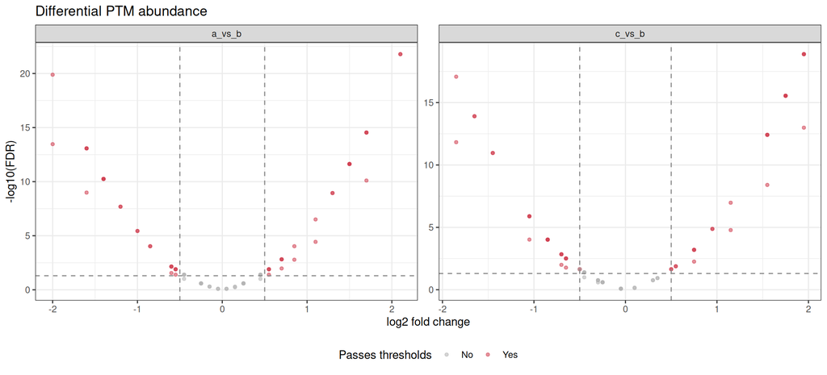

Figure 1: Differential PTM abundance by contrast. Each point is one PTM site; the x-axis is its site-level log2 fold change and the y-axis is -log10(FDR). Red points pass the displayed absolute fold-change and FDR thresholds.

**Site vs protein**

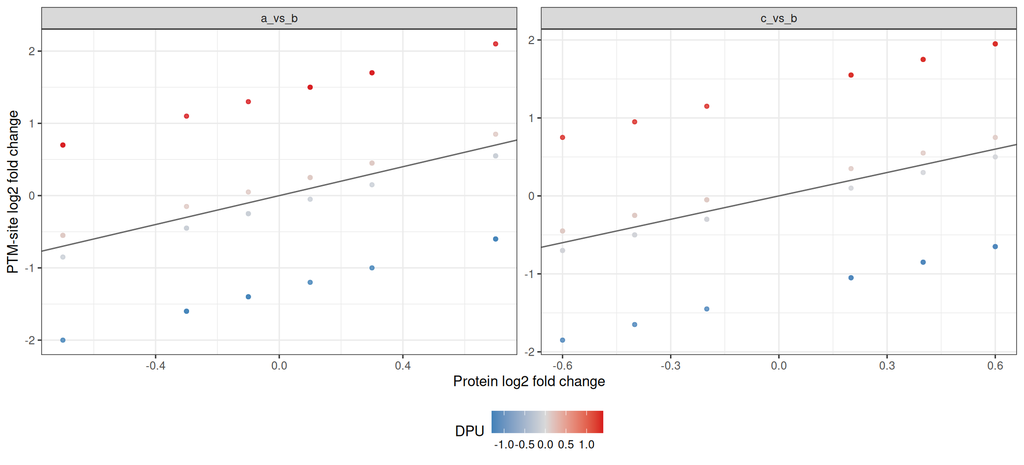

Figure 2: PTM-site log2 fold change as a function of the matched protein log2 fold change. Each point is one matched site; the diagonal denotes equal site and protein change, and colour is their difference, the DPU effect.

**Sequence logos**

**Plot**

The logos use significant, sequence-validated PTM sites and separate each contrast and regulation direction. Panel labels report the number of sites; letter height is the amino-acid probability at that position. **On-render selection:** FDR < 0.05 and |log2 fold change| > 0.5.

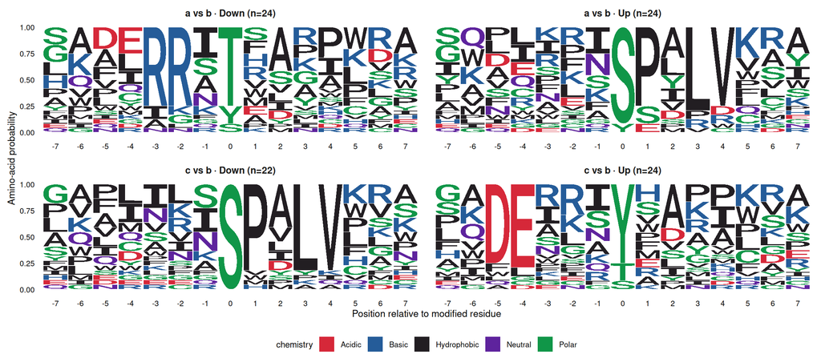

Figure 3: Sequence motifs around differentially abundant PTM sites. Each panel contains one contrast and regulation direction after applying the displayed FDR and absolute fold-change thresholds.

**Table**

Table 6: DPA sites entering the sequence logos by contrast, direction, and modified residue.

| Contrast | Direction | Modified residue | Sites |
| --- | --- | --- | --- |
| a vs b | Down | S | 2 |
| a vs b | Down | T | 18 |
| a vs b | Down | Y | 4 |
| a vs b | Up | S | 22 |
| a vs b | Up | Y | 2 |
| c vs b | Down | S | 22 |
| c vs b | Up | S | 2 |
| c vs b | Up | T | 4 |
| c vs b | Up | Y | 18 |

**Difference logos**

These logos are recomputed from MuData during rendering using **FDR < 0.05 and |log2 fold change| > 0.5**.

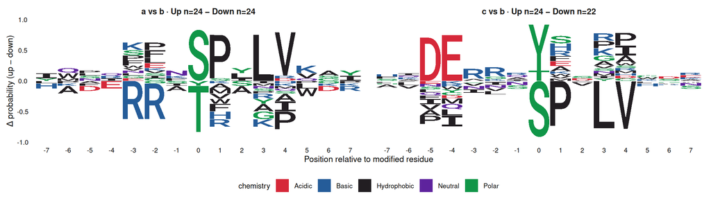

Figure 4: Difference logos for DPA. Letters above zero are enriched around upregulated sites; letters below zero are enriched around downregulated sites in the same contrast.

**Results**

Table 7

| protein_Id | site | gene_name.site | modAA | posInProtein | SequenceWindow | contrast | diff.site | FDR.site | diff.protein | FDR.protein | estimate_type.site |
| --- | --- | --- | --- | --- | --- | --- | --- | --- | --- | --- | --- |
| P001 | P001~S10 | GENE001 | S | 10 | GAQDILISPALVPGP | a_vs_b | 0.7000000000000016 | 0.01059982849081081 | -0.7000000000000011 | 0.0003630781097496983 | observed |
| P001 | P001~T20 | GENE001 | T | 20 | GAQDRRITMAKAPGP | a_vs_b | -1.999999999999996 | 3.403082463686647e-14 | -0.7000000000000011 | 0.0003630781097496983 | observed |
| P001 | P001~Y30 | GENE001 | Y | 30 | GADEILIYMAKAPGP | a_vs_b | -0.5499999999999959 | 0.03996976805969493 | -0.7000000000000011 | 0.0003630781097496983 | observed |
| P002 | P002~S10 | GENE002 | S | 10 | GAQDILISMAKAPGP | a_vs_b | -0.4499999999999988 | 0.09739660416599627 | -0.3000000000000018 | 0.08361708684329533 | observed |
| P002 | P002~S20 | GENE002 | S | 20 | AQVWERSSPLLVKYS | a_vs_b | 1.100000000000006 | 3.682272149857437e-05 | -0.3000000000000018 | 0.08361708684329533 | observed |
| P002 | P002~T30 | GENE002 | T | 30 | AQVWRRSTSLNVKYS | a_vs_b | -1.599999999999999 | 1.024281944615591e-09 | -0.3000000000000018 | 0.08361708684329533 | observed |
| P003 | P003~S20 | GENE003 | S | 20 | AQVWERSSSLNVKYS | a_vs_b | 0.1500000000000021 | 0.5864091759120575 | 0.2999999999999982 | 0.08361708684329533 | observed |
| P003 | P003~S30 | GENE003 | S | 30 | IWLQKPISPLLVKAY | a_vs_b | 1.700000000000008 | 7.875452492137038e-11 | 0.2999999999999982 | 0.08361708684329533 | observed |
| P003 | P003~Y10 | GENE003 | Y | 10 | AQDEERSYSLNVKYS | a_vs_b | 0.450000000000001 | 0.09739660416599627 | 0.2999999999999982 | 0.08361708684329533 | observed |
| P004 | P004~S30 | GENE004 | S | 30 | IWLQKPISSLPDKAY | a_vs_b | 0.55 | 0.03996976805969493 | 0.6999999999999963 | 0.0003630781097496983 | observed |

[output cut: 134 more lines]

**DPU**

**Summary**

Differential PTM usage compares the modelled site change with the modelled protein change. A positive value means the site increased more than its protein; a negative value means it increased less or decreased more. Only a site whose protein has a result has a usage change, so DPU holds the matched sites.

Table 8: DPU site-contrast rows by site estimate type. All are computed; this report shows only the observed ones; their protein estimate may be imputed.

| contrast | observed | total |
| --- | --- | --- |
| a_vs_b | 72 | 72 |
| c_vs_b | 72 | 72 |

Table 9: Observed DPU rows by contrast and modified amino acid.

| contrast | modAA | sites |
| --- | --- | --- |
| a_vs_b | S | 36 |
| a_vs_b | T | 18 |
| a_vs_b | Y | 18 |
| c_vs_b | S | 36 |
| c_vs_b | T | 18 |
| c_vs_b | Y | 18 |

**Volcano**

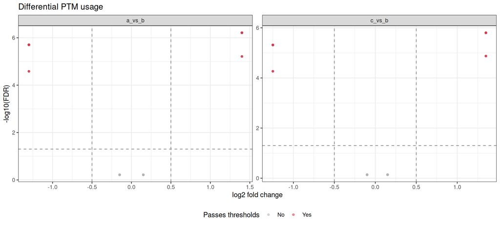

Figure 5: Differential PTM usage by contrast. Each point is one PTM site; the x-axis is the site-minus-protein log2 fold change and the y-axis is -log10(FDR) after propagated site and protein uncertainty. Red points pass both displayed thresholds.

**Site vs protein**

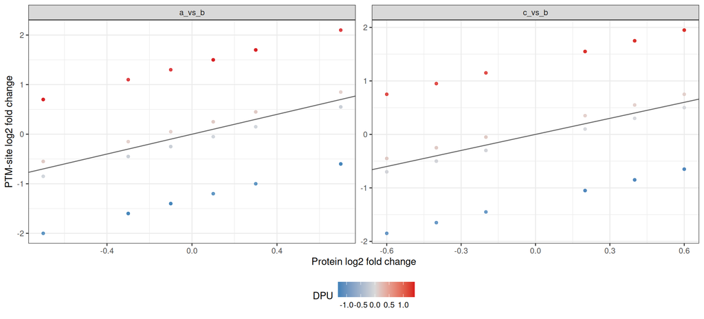

Figure 6: Site and protein log2 fold changes used to calculate DPU. Points above the diagonal have positive PTM usage changes and points below it have negative usage changes; colour shows the signed site-minus-protein difference.

**Sequence logos**

**Plot**

The DPU logos group sites by the direction of their protein-adjusted change. Panel labels report the number of sites entering each motif. **On-render selection:** FDR < 0.05 and |log2 fold change| > 0.5.

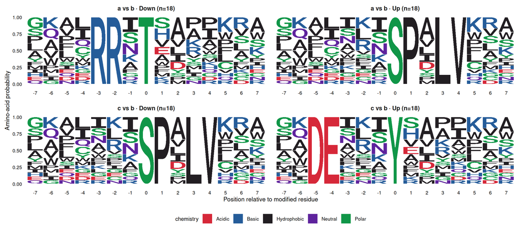

Figure 7: Sequence motifs around sites with significant differential PTM usage, separated by contrast and direction.

**Table**

Table 10: DPU sites entering the sequence logos by contrast, direction, and modified residue.

| Contrast | Direction | Modified residue | Sites |
| --- | --- | --- | --- |
| a vs b | Down | T | 18 |
| a vs b | Up | S | 18 |
| c vs b | Down | S | 18 |
| c vs b | Up | Y | 18 |

**Difference logos**

These logos are recomputed from MuData during rendering using **FDR < 0.05 and |log2 fold change| > 0.5**.

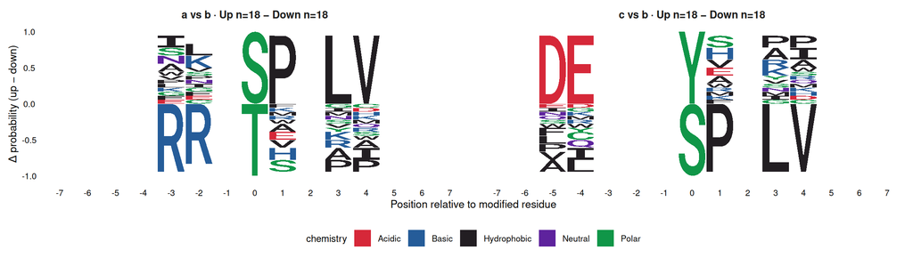

Figure 8: Difference logos for DPU, showing the amino-acid probability around upregulated sites minus that around downregulated sites in each contrast.

**Results**

Table 11

| protein_Id | site | gene_name.site | modAA | posInProtein | SequenceWindow | contrast | diff.site | diff.protein | diff_diff | SE_I | pValue_I | FDR_I |
| --- | --- | --- | --- | --- | --- | --- | --- | --- | --- | --- | --- | --- |
| P001 | P001~S10 | GENE001 | S | 10 | GAQDILISPALVPGP | a_vs_b | 0.7000000000000016 | -0.7000000000000011 | 1.400000000000003 | 0.2933546510985048 | 2.812135973922884e-06 | 6.139622509580129e-06 |
| P001 | P001~T20 | GENE001 | T | 20 | GAQDRRITMAKAPGP | a_vs_b | -1.999999999999996 | -0.7000000000000011 | -1.299999999999995 | 0.2933568916197828 | 1.301070026792461e-05 | 2.603714493128742e-05 |
| P001 | P001~Y30 | GENE001 | Y | 30 | GADEILIYMAKAPGP | a_vs_b | -0.5499999999999959 | -0.7000000000000011 | 0.1500000000000051 | 0.293359216670941 | 0.6094928948914518 | 0.6094988479501638 |
| P002 | P002~S10 | GENE002 | S | 10 | GAQDILISMAKAPGP | a_vs_b | -0.4499999999999988 | -0.3000000000000018 | -0.149999999999997 | 0.2933616262499694 | 0.6094958201351146 | 0.6094988479501638 |
| P002 | P002~S20 | GENE002 | S | 20 | AQVWERSSPLLVKYS | a_vs_b | 1.100000000000006 | -0.3000000000000018 | 1.400000000000007 | 0.2933641203547851 | 2.813993650224226e-06 | 6.139622509580129e-06 |
| P002 | P002~T30 | GENE002 | T | 30 | AQVWRRSTSLNVKYS | a_vs_b | -1.599999999999999 | -0.3000000000000018 | -1.299999999999998 | 0.2933666989832325 | 1.301857246564371e-05 | 2.603714493128742e-05 |
| P003 | P003~S20 | GENE003 | S | 20 | AQVWERSSSLNVKYS | a_vs_b | 0.1500000000000021 | 0.2999999999999982 | -0.1499999999999961 | 0.2933546510985048 | 0.6094873521456223 | 0.6094988479501638 |
| P003 | P003~S30 | GENE003 | S | 30 | IWLQKPISPLLVKAY | a_vs_b | 1.700000000000008 | 0.2999999999999982 | 1.40000000000001 | 0.2933568916197828 | 2.812575419215022e-06 | 6.139622509580129e-06 |
| P003 | P003~Y10 | GENE003 | Y | 10 | AQDEERSYSLNVKYS | a_vs_b | 0.450000000000001 | 0.2999999999999982 | 0.1500000000000028 | 0.2933524951090437 | 0.6094847346564094 | 0.6094988479501638 |
| P004 | P004~S30 | GENE004 | S | 30 | IWLQKPISSLPDKAY | a_vs_b | 0.55 | 0.6999999999999963 | -0.1499999999999962 | 0.2933641203547851 | 0.6094988479501638 | 0.6094988479501638 |

[output cut: 134 more lines]

**CorrectFirst DPU**

**Summary**

CorrectFirst subtracts the protein abundance from the site abundance on the log2 scale and adds back the sample’s median protein abundance before modelling. A protein value missing in a sample is taken from the protein DEA’s `lm_impute` model, so every site whose protein was quantified is corrected. The fitted site effect is then the change in PTM usage.

Table 12: CorrectFirst site-contrast rows by estimate type. All are computed; this report shows only the observed ones.

| contrast | observed | total |
| --- | --- | --- |
| a_vs_b | 72 | 72 |
| c_vs_b | 72 | 72 |

Table 13: Observed CorrectFirst rows by contrast and modified amino acid.

| contrast | modAA | sites |
| --- | --- | --- |
| a_vs_b | S | 36 |
| a_vs_b | T | 18 |
| a_vs_b | Y | 18 |
| c_vs_b | S | 36 |
| c_vs_b | T | 18 |
| c_vs_b | Y | 18 |

**Quality control**

The two plots assess the protein-corrected sample-level values entering the CorrectFirst model.

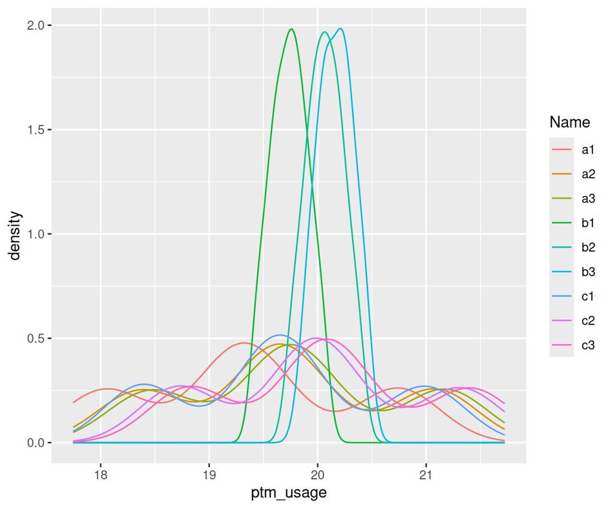

Figure 9: Distribution of protein-corrected log2 PTM-site abundance by sample. Each curve is one sample; shifts or shape differences indicate global changes in the corrected values entering the CorrectFirst model.

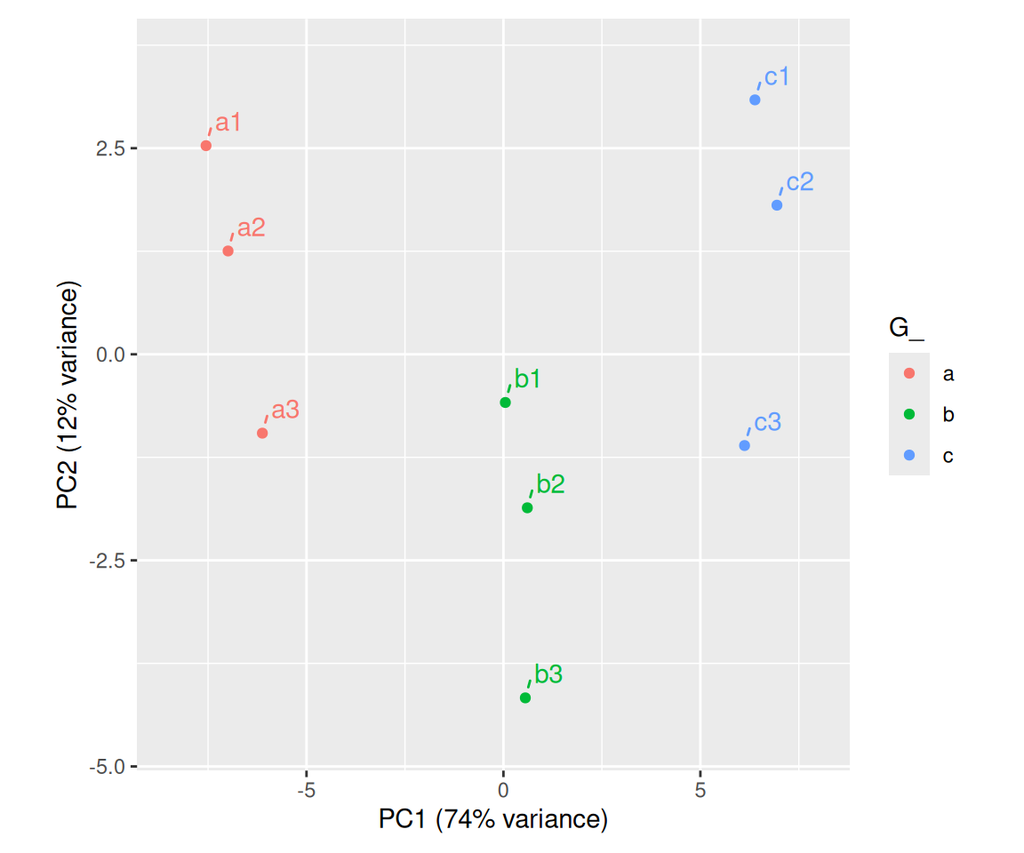

Figure 10: Principal-component analysis of protein-corrected PTM-site abundances. Points are samples, coloured by experimental group; the projection uses imputation only for visualization and does not refit the statistical model.

**Volcano**

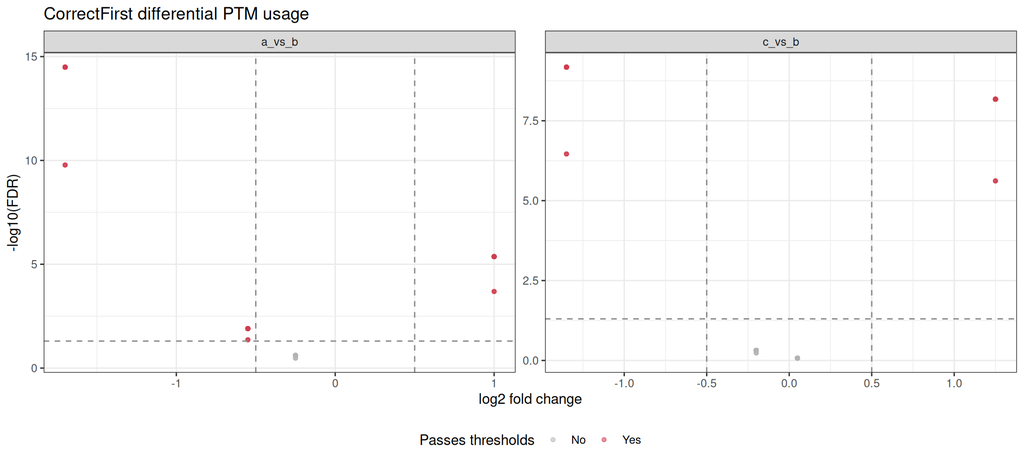

Figure 11: CorrectFirst differential PTM usage by contrast. Each point is one PTM site modelled after sample-level protein correction; the x-axis is its log2 fold change and the y-axis is -log10(FDR). Red points pass both displayed thresholds.

**Sequence logos**

**Plot**

The CorrectFirst logos use the direction of the effect fitted after sample-level protein correction. Panel labels report the number of sites entering each motif. **On-render selection:** FDR < 0.05 and |log2 fold change| > 0.5.

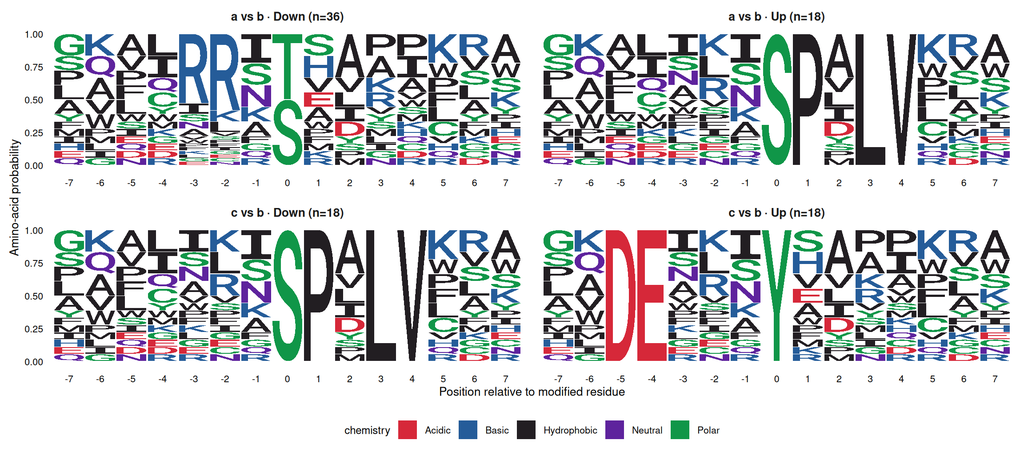

Figure 12: Sequence motifs around sites with significant CorrectFirst differential PTM usage, separated by contrast and direction.

**Table**

Table 14: CorrectFirst sites entering the sequence logos by contrast, direction, and modified residue.

| Contrast | Direction | Modified residue | Sites |
| --- | --- | --- | --- |
| a vs b | Down | S | 18 |
| a vs b | Down | T | 18 |
| a vs b | Up | S | 18 |
| c vs b | Down | S | 18 |
| c vs b | Up | Y | 18 |

**Difference logos**

These logos are recomputed from MuData during rendering using **FDR < 0.05 and |log2 fold change| > 0.5**.

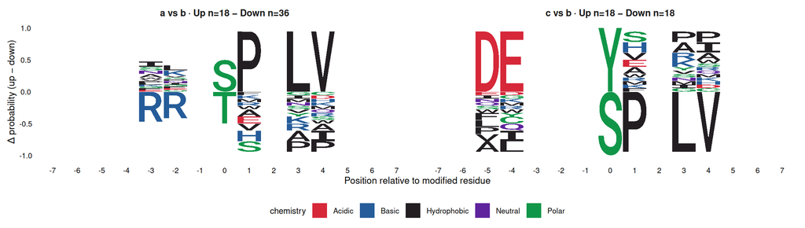

Figure 13: Difference logos for CorrectFirst DPU, showing the amino-acid probability around upregulated sites minus that around downregulated sites.

**Results**

Table 15

| protein_Id | site | gene_name | modAA | posInProtein | SequenceWindow | contrast | diff.site | std.error | statistic.site | p.value | FDR.site | estimate_type |
| --- | --- | --- | --- | --- | --- | --- | --- | --- | --- | --- | --- | --- |
| P001 | P001~S10 | GENE001 | S | 10 | GAQDILISPALVPGP | a_vs_b | 1.000000000000004 | 0.2572837305265261 | 3.88675956289006 | 0.0001023980495947898 | 0.0002049044143146127 | observed |
| P001 | P001~T20 | GENE001 | T | 20 | GAQDRRITMAKAPGP | a_vs_b | -1.700000000000001 | 0.2572864222856777 | -6.607422128605013 | 4.156655605834002e-11 | 1.665190712624488e-10 | observed |
| P001 | P001~Y30 | GENE001 | Y | 30 | GADEILIYMAKAPGP | a_vs_b | -0.2500000000000001 | 0.2572892104165147 | -0.9716691951259268 | 0.3312440258203381 | 0.3312440258203381 | observed |
| P002 | P002~S10 | GENE002 | S | 10 | GAQDILISMAKAPGP | a_vs_b | -0.5499999999999959 | 0.2572893572514078 | -2.13767100930867 | 0.03257316384179713 | 0.04343088512239618 | observed |
| P002 | P002~S20 | GENE002 | S | 20 | AQVWERSSPLLVKYS | a_vs_b | 1.000000000000003 | 0.2572922467352903 | 3.886630913635077 | 0.0001024522071573063 | 0.0002049044143146127 | observed |
| P002 | P002~T30 | GENE002 | T | 30 | AQVWRRSTSLNVKYS | a_vs_b | -1.699999999999995 | 0.2572952325843135 | -6.607195877377629 | 4.16297678156122e-11 | 1.665190712624488e-10 | observed |
| P003 | P003~S20 | GENE003 | S | 20 | AQVWERSSSLNVKYS | a_vs_b | -0.549999999999996 | 0.2572788901837784 | -2.137757977761496 | 0.03256609870518314 | 0.04343088512239618 | observed |
| P003 | P003~S30 | GENE003 | S | 30 | IWLQKPISPLLVKAY | a_vs_b | 1.000000000000005 | 0.2572813991608244 | 3.886794782917492 | 0.0001023832277092622 | 0.0002049044143146127 | observed |
| P003 | P003~Y10 | GENE003 | Y | 10 | AQDEERSYSLNVKYS | a_vs_b | -0.2499999999999943 | 0.2572764775868822 | -0.9717172838530072 | 0.331220096578653 | 0.3312440258203381 | observed |
| P004 | P004~S30 | GENE004 | S | 30 | IWLQKPISSLPDKAY | a_vs_b | -0.5499999999999923 | 0.2572868486098757 | -2.137691852388296 | 0.03257147047364045 | 0.04343088512239618 | observed |

[output cut: 134 more lines]

**Session Info**

**Report provenance**

Table 16: Report provenance and the final MuData input reference.

|  | Field | Value |
| --- | --- | --- |
| 1 | Input MuData | /home/runner/work/_temp/Library/prophosqua/extdata/ptm_results_example/PTM_results.h5mu |
| 3 | Contrasts | a_vs_b; c_vs_b |
| 4 | FDR threshold | 0.05 |
| 5 | Absolute log2 fold-change threshold | 0.5 |
| 6 | Report package | prophosqua 0.3.0 |
| 7 | Generated at | 2026-10-21 09:09:51 UTC |
| 8 | Qmd source | ptm_statistics.qmd |

**R session info**

## Download

- Qmd source
- HTML page